# Computational Statistics - Model Selection

4/29/2022

# 1 Introduction

This data set was taken from the UCI repository. It contains the medical records of 299 patients who were diagnosed with heart failure. The data was collected during a follow-up period where each patient had 13 clinical features examined. The data was collected by Davide Chicco and Guiseppe Jurman in 2020 for their research paper “Machine learning can predict survival of patients with heart failure from serum creatinine and ejection fraction alone”.

The purpose of this project is to predict which features are more statistically significant in regards to death event. We intend to focus on model selection and other different statistical prediction methods. Our results will be detailed below.

The limitations to this data set is that it is relatively small which means that even after finding the best model – we would run into problems with under fitting.

## 1.1 Variable Description

Thirteen (13) clinical features:

- age: age of the patient (years)
- anaemia: decrease of red blood cells or hemoglobin (boolean)
- high blood pressure: if the patient has hypertension (boolean)
- creatinine phosphokinase (CPK): level of the CPK enzyme in the blood (mcg/L). When a muscle tissue gets damaged, CPK flows into the blood. Therefore, high levels of CPK in the blood of a patient might indicate a heart failure or injury
- diabetes: if the patient has diabetes (boolean)
- ejection fraction: blood leaving the left ventricle pumps at each contraction (percentage)
- platelets: platelets in the blood (kiloplatelets/mL)
- sex: woman(0) or man(1) (binary)
- serum creatinine: level of serum creatinine, which is a waste product generated by creatine, when a muscle breaks down, in the blood (mg/dL). Especially, doctors focus on serum creatinine in blood to check kidney function.
- serum sodium: level of serum sodium in the blood (mEq/L). An abnormally low level of sodium in the blood might be caused by heart failure.
- smoking: if the patient smokes or not (boolean)
- time: follow-up period (days)
- [target] death event: if the patient deceased during the follow-up period (boolean)

# 2 Data Cleaning

```r
head(heartdata)
```

```
##   age anaemia creatinine_phosphokinase diabetes ejection_fraction
## 1  75       0                      582        0                20
## 2  55       0                     7861        0                38
## 3  65       0                      146        0                20
## 4  50       1                      111        0                20
## 5  65       1                      160        1                20
## 6  90       1                       47        0                40
##   high_blood_pressure platelets serum_creatinine serum_sodium sex smoking time
## 1                   1    265000              1.9          130   1       0    4
## 2                   0    263358              1.1          136   1       0    6
## 3                   0    162000              1.3          129   1       1    7
## 4                   0    210000              1.9          137   1       0    7
## 5                   0    327000              2.7          116   0       0    8
## 6                   1    204000              2.1          132   1       1    8
##   DEATH_EVENT
## 1           1
## 2           1
## 3           1
## 4           1
## 5           1
## 6           1
```

```r
sum(is.na(heartdata))
```

```
## [1] 0
```

```r
sum(duplicated(heartdata))
```

```
## [1] 0
```

The data set contains 0 null values, and 0 duplicated observations.

```r
str(heartdata)
```

```
## 'data.frame':    299 obs. of  13 variables:
##  $ age                     : num  75 55 65 50 65 90 75 60 65 80 ...
##  $ anaemia                 : int  0 0 0 1 1 1 1 1 0 1 ...
##  $ creatinine_phosphokinase: int  582 7861 146 111 160 47 246 315 157 123 ...
##  $ diabetes                : int  0 0 0 0 1 0 0 1 0 0 ...
##  $ ejection_fraction       : int  20 38 20 20 20 40 15 60 65 35 ...
##  $ high_blood_pressure     : int  1 0 0 0 0 1 0 0 0 1 ...
##  $ platelets               : num  265000 263358 162000 210000 327000 ...
##  $ serum_creatinine        : num  1.9 1.1 1.3 1.9 2.7 2.1 1.2 1.1 1.5 9.4 ...
##  $ serum_sodium            : int  130 136 129 137 116 132 137 131 138 133 ...
##  $ sex                     : int  1 1 1 1 0 1 1 1 0 1 ...
##  $ smoking                 : int  0 0 1 0 0 1 0 1 0 1 ...
##  $ time                    : int  4 6 7 7 8 8 10 10 10 10 ...
##  $ DEATH_EVENT             : int  1 1 1 1 1 1 1 1 1 1 ...
```

The variables anaemaia, smoking, sex, diabetes, high blood pressure and Death event should be categorical. This correction is made in the next block.

```r
# Making correction in Data Type:----'
categoricalcolumns <- c("anaemia","smoking","sex","diabetes","DEATH_EVENT","high_blood_pressure")
for( i in categoricalcolumns){
heartdata[,i] <- as.factor(heartdata[,i])
}
str(heartdata)
```

```
## 'data.frame':    299 obs. of  13 variables:
##  $ age                     : num  75 55 65 50 65 90 75 60 65 80 ...
##  $ anaemia                 : Factor w/ 2 levels "0","1": 1 1 1 2 2 2 2 2 1 2 ...
##  $ creatinine_phosphokinase: int  582 7861 146 111 160 47 246 315 157 123 ...
##  $ diabetes                : Factor w/ 2 levels "0","1": 1 1 1 1 2 1 1 2 1 1 ...
##  $ ejection_fraction       : int  20 38 20 20 20 40 15 60 65 35 ...
##  $ high_blood_pressure     : Factor w/ 2 levels "0","1": 2 1 1 1 1 2 1 1 1 2 ...
##  $ platelets               : num  265000 263358 162000 210000 327000 ...
##  $ serum_creatinine        : num  1.9 1.1 1.3 1.9 2.7 2.1 1.2 1.1 1.5 9.4 ...
##  $ serum_sodium            : int  130 136 129 137 116 132 137 131 138 133 ...
##  $ sex                     : Factor w/ 2 levels "0","1": 2 2 2 2 1 2 2 2 1 2 ...
##  $ smoking                 : Factor w/ 2 levels "0","1": 1 1 2 1 1 2 1 2 1 2 ...
##  $ time                    : int  4 6 7 7 8 8 10 10 10 10 ...
##  $ DEATH_EVENT             : Factor w/ 2 levels "0","1": 2 2 2 2 2 2 2 2 2 2 ...
```

The variables are now converted to categorical.

# 3 Descriptive Statistics

```r
summary(heartdata)
```

```
##       age        anaemia creatinine_phosphokinase diabetes ejection_fraction
##  Min.   :40.00   0:170   Min.   :  23.0           0:174    Min.   :14.00
##  1st Qu.:51.00   1:129   1st Qu.: 116.5           1:125    1st Qu.:30.00
##  Median :60.00           Median : 250.0                    Median :38.00
##  Mean   :60.83           Mean   : 581.8                    Mean   :38.08
##  3rd Qu.:70.00           3rd Qu.: 582.0                    3rd Qu.:45.00
##  Max.   :95.00           Max.   :7861.0                    Max.   :80.00
##  high_blood_pressure   platelets      serum_creatinine  serum_sodium   sex
##  0:194               Min.   : 25100   Min.   :0.500    Min.   :113.0   0:105
##  1:105               1st Qu.:212500   1st Qu.:0.900    1st Qu.:134.0   1:194
##                      Median :262000   Median :1.100    Median :137.0
##                      Mean   :263358   Mean   :1.394    Mean   :136.6
##                      3rd Qu.:303500   3rd Qu.:1.400    3rd Qu.:140.0
##                      Max.   :850000   Max.   :9.400    Max.   :148.0
##  smoking      time       DEATH_EVENT
##  0:203   Min.   :  4.0   0:203
##  1: 96   1st Qu.: 73.0   1: 96
##          Median :115.0
##          Mean   :130.3
##          3rd Qu.:203.0
##          Max.   :285.0
```

# 4 Data Visualization

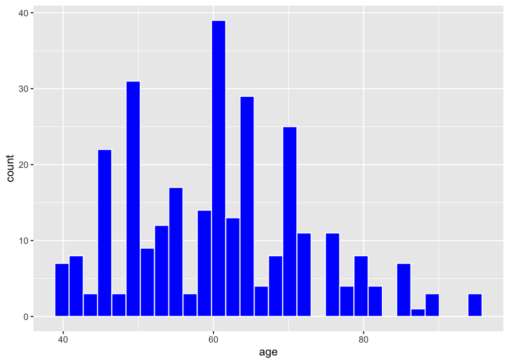

```r
library(ggplot2)
ggplot(heartdata, aes(x=age)) +
geom_histogram(color="white", fill="blue")
```

This plot shows that the of the sample was between 40 and 95 years old. With the majority of participants being around 60 years old. The distribution of age appears to be normal distribution as visible from the plot.

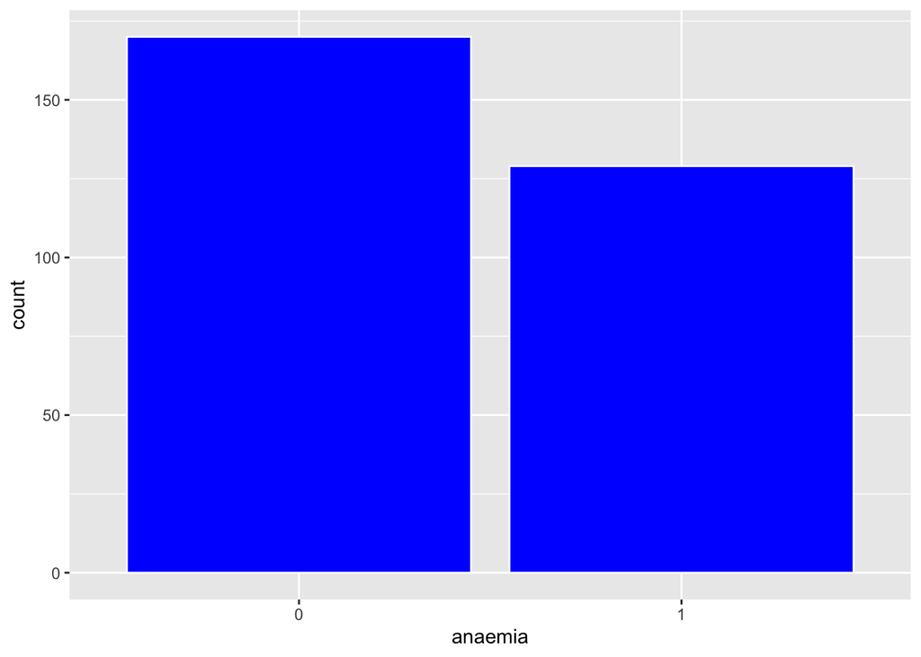

```r
ggplot(heartdata, aes(x=anaemia)) +
geom_bar(color="white", fill="blue")
```

More people in the study did not have anaemia, but a good amount still did. We can continue with the analysis based on this data.

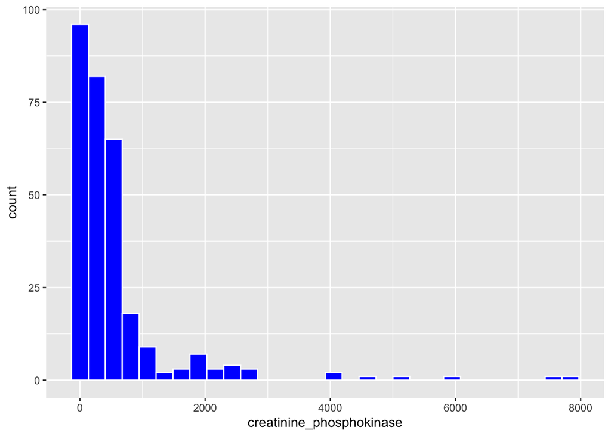

```r
ggplot(heartdata, aes(x=creatinine_phosphokinase)) +
geom_histogram(color="white", fill="blue")
```

The majority of people in the study had creatinine phosphokinase levels below 2000, but the range was up to 8000.

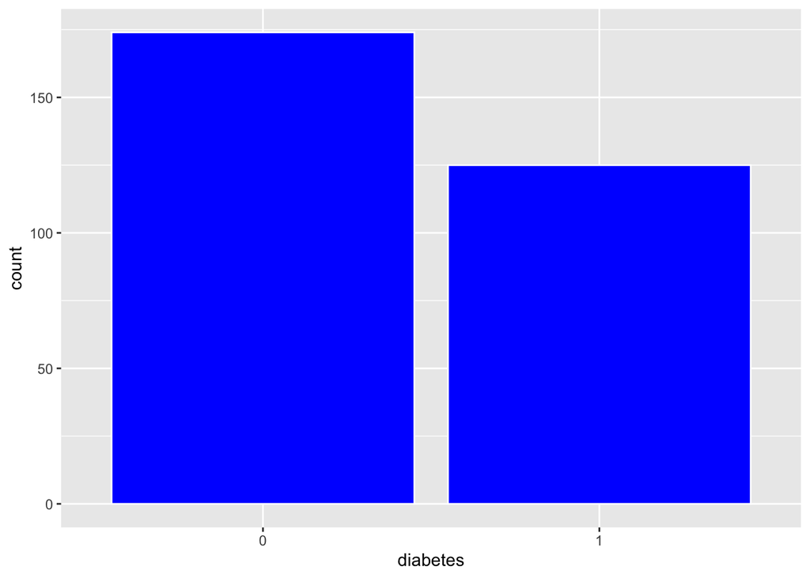

```r
ggplot(heartdata, aes(x=diabetes)) +
geom_bar(color="white", fill="blue")
```

The majority of participants did not have diabetes, but a good amount did. We can continue with the analysis based on this data.

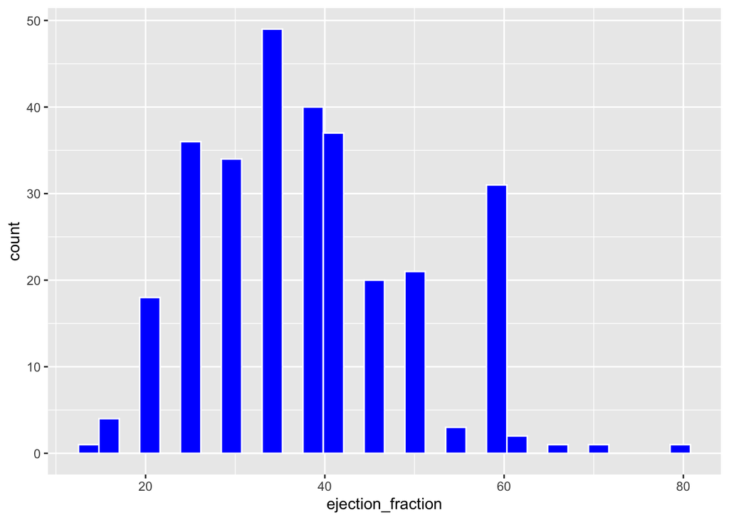

```r
ggplot(heartdata, aes(x=ejection_fraction)) +
geom_histogram(color="white", fill="blue")
```

The majority of patients were under 55% for their ejection fraction. Normal EF is in the range of 55% to 70%. As the percentage falls, it tells the doctor that the heart failure is getting worse. In general, if the EF falls below 30%, it’s relatively severe. A reading of 20% or below is very severe heart failure. EF above 75% is considered too high, and can be a problem as well.

Source: https://www.webmd.com/heart-disease/heart-failure/features/ejection-fraction

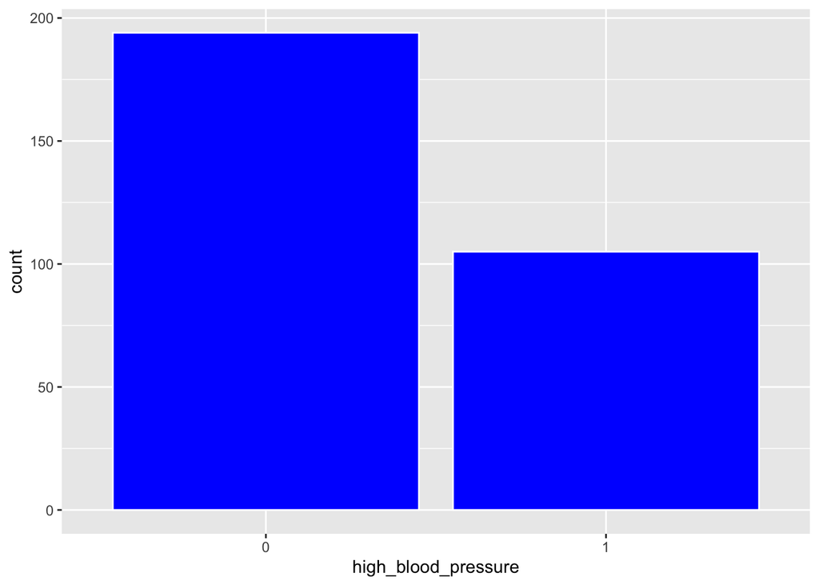

```r
ggplot(heartdata, aes(x=high_blood_pressure)) +
geom_bar(color="white", fill="blue")
```

Most patients did not have high blood pressure.

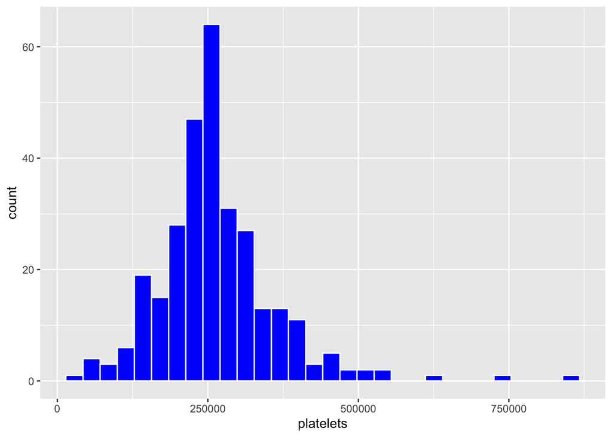

```r
ggplot(heartdata, aes(x=platelets)) +
geom_histogram(color="white", fill="blue")
```

The platelets follow a normal distribution. A normal platelet count ranges from 150,000 to 450,000 kiloplatelets per milliliter of blood.

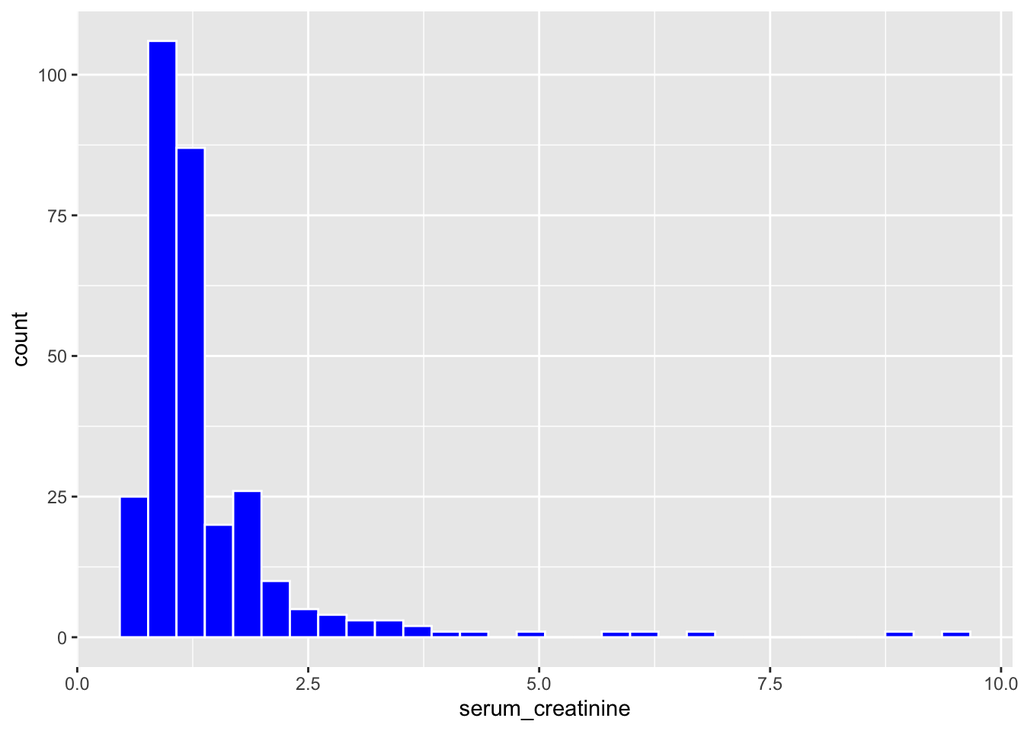

```r
ggplot(heartdata, aes(x=serum_creatinine)) +
geom_histogram(color="white", fill="blue")
```

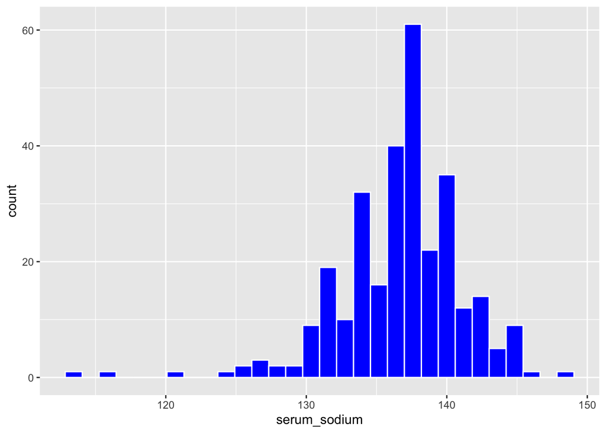

```r
ggplot(heartdata, aes(x=serum_sodium)) +
geom_histogram(color="white", fill="blue")
```

A normal blood sodium level is between 135 and 145 milliequivalents per liter (mEq/L). Most patients were in the normal range.

Source: https://www.mayoclinic.org/diseases-conditions/hyponatremia/symptoms-causes/syc-20373711#

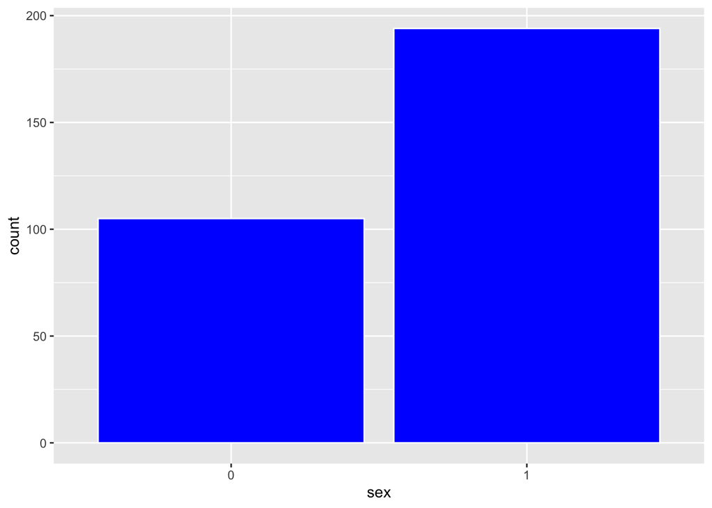

```r
ggplot(heartdata, aes(x=sex)) +
geom_bar(color="white", fill="blue")
```

More patients in the study were male.

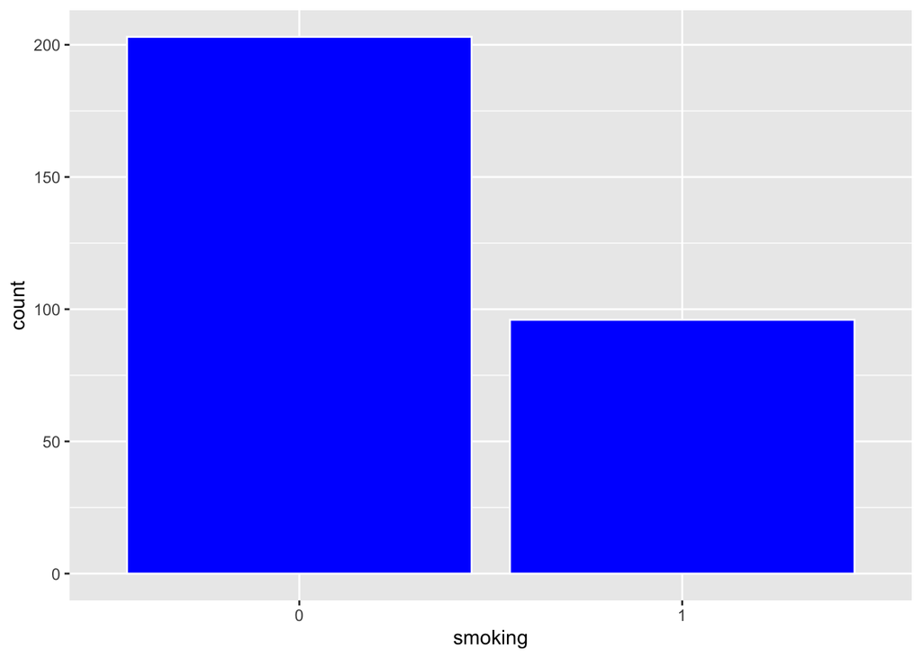

```r
ggplot(heartdata, aes(x=smoking)) +
geom_bar(color="white", fill="blue")
```

More patients did not smoke compared to smoking.

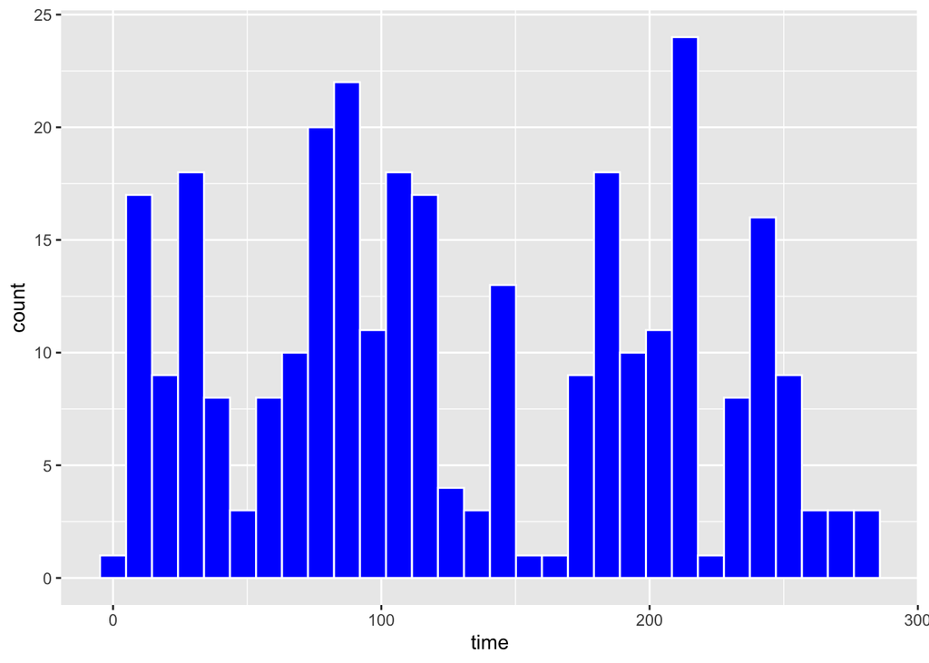

```r
ggplot(heartdata, aes(x=time)) +
geom_histogram(color="white", fill="blue")
```

There was no real distribution for time after follow up.

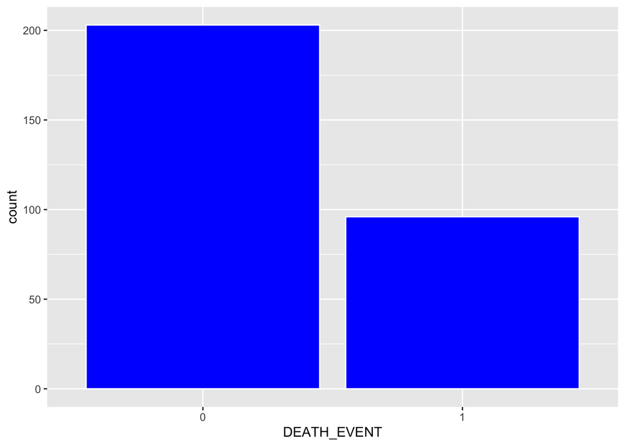

```r
ggplot(heartdata, aes(x=DEATH_EVENT)) +
geom_bar(color="white", fill="blue")
```

More people survived in the study during the follow up period.

# 5 Model Selection - Logistic Regression

## 5.1 Checking Assumptions for Logistic Regression

### 5.1.1 Assumption 1: Binary Outcome (DEATH_EVENT)

An important assumption of logistic regression is that the outcomes should be binary. This assumption is satisfied.

```r
table(heartdata$DEATH_EVENT)
```

```
##
##   0   1
## 203  96
```

### 5.1.2 Assumption 2: Linear Relationship between logit function and each continuous predictor

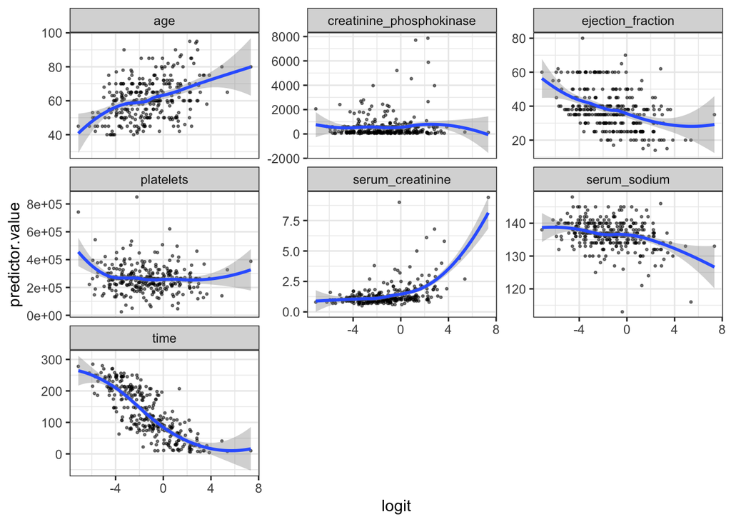

```r
# Applying Model
model_test <- glm(DEATH_EVENT ~ ., family = binomial,
              data = heartdata)
probabilities <- predict(model_test, type = "response")

data_check <- heartdata %>% select_if(is.numeric)
predictors <- colnames(data_check)

# Bind the logit and tidying the data for plot
mydata <- data_check %>%
  mutate(logit = log(probabilities/(1-probabilities))) %>%
  gather(key = "predictors", value = "predictor.value", -logit)

ggplot(mydata, aes(logit, predictor.value))+
  geom_point(size = 0.5, alpha = 0.5) +
  geom_smooth(method = "loess") +
  theme_bw() +
  facet_wrap(~predictors, scales = "free_y")
```

### 5.1.3 Assumption 3: Influential Value in predictors

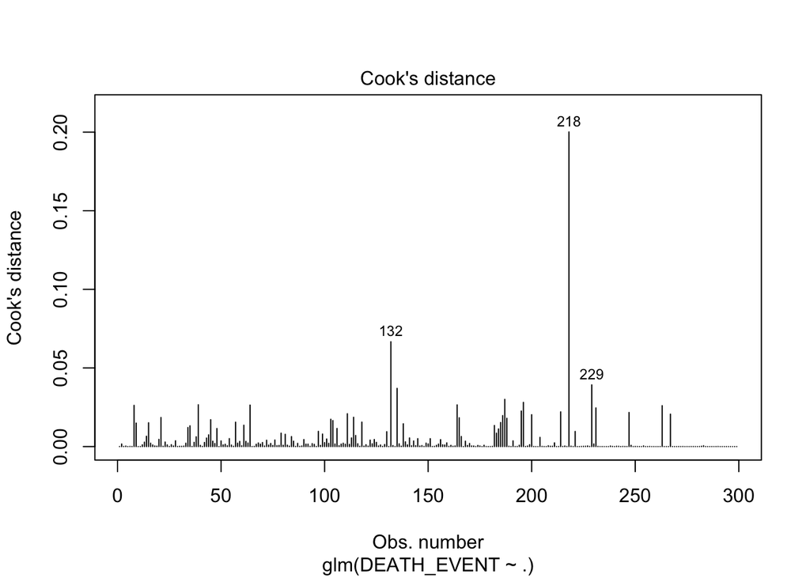

```r
plot(model_test, which = 4, id.n = 3) # Gives Influential Values based on observations.
```

```r
model.data <- augment(model_test) %>%
  mutate(index = 1:n())
model.data %>% top_n(3, .cooksd)
```

```
## # A tibble: 3 × 20
##   DEATH_EVENT   age anaemia creatinine_phosphokinase diabetes ejection_fraction
##   <fct>       <dbl> <fct>                      <int> <fct>                <int>
## 1 0              60 1                           1082 1                       45
## 2 1              54 1                            427 0                       70
## 3 0              65 0                             56 0                       25
## # … with 14 more variables: high_blood_pressure <fct>, platelets <dbl>,
## #   serum_creatinine <dbl>, serum_sodium <int>, sex <fct>, smoking <fct>,
## #   time <int>, .fitted <dbl>, .resid <dbl>, .std.resid <dbl>, .hat <dbl>,
## #   .sigma <dbl>, .cooksd <dbl>, index <int>
```

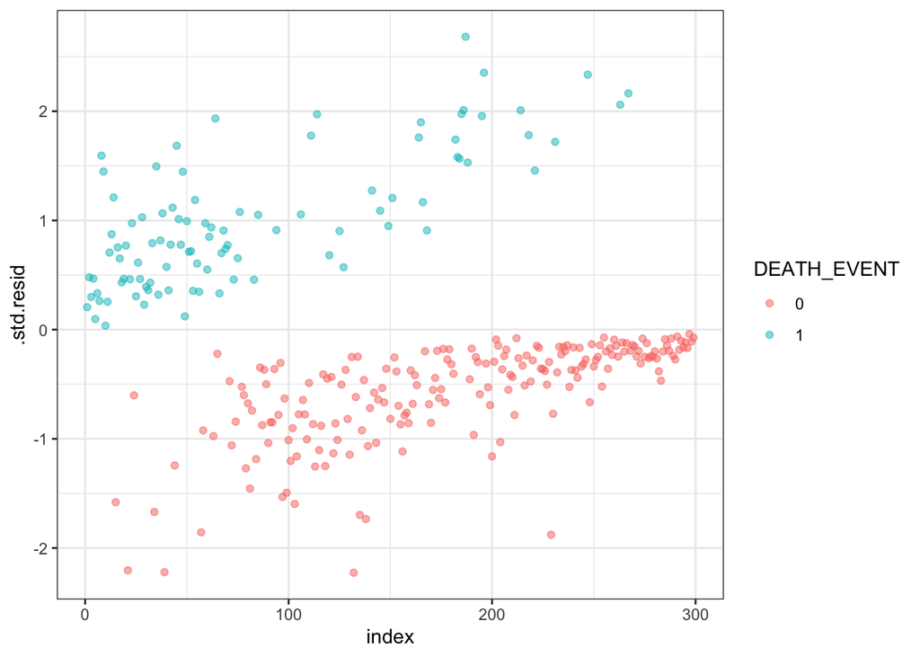

```r
ggplot(model.data, aes(index, .std.resid)) +
  geom_point(aes(color = DEATH_EVENT), alpha = .5) +
  theme_bw()
```

```r
model.data %>%
  filter(abs(.std.resid) > 3)
```

```
## # A tibble: 0 × 20
## # … with 20 variables: DEATH_EVENT <fct>, age <dbl>, anaemia <fct>,
## #   creatinine_phosphokinase <int>, diabetes <fct>, ejection_fraction <int>,
## #   high_blood_pressure <fct>, platelets <dbl>, serum_creatinine <dbl>,
## #   serum_sodium <int>, sex <fct>, smoking <fct>, time <int>, .fitted <dbl>,
## #   .resid <dbl>, .std.resid <dbl>, .hat <dbl>, .sigma <dbl>, .cooksd <dbl>,
## #   index <int>
```

No influential measures were found.

### 5.1.4 Assumption 4: Multicollinearity

All the values are less than 4, so multicollinearity assumption hold true, meaning that no multicollinearity exists.

```r
car::vif(model_test)
```

```
##                      age                  anaemia creatinine_phosphokinase
##                 1.104307                 1.114540                 1.085629
##                 diabetes        ejection_fraction      high_blood_pressure
##                 1.052375                 1.172842                 1.063014
##                platelets         serum_creatinine             serum_sodium
##                 1.045319                 1.102088                 1.070685
##                      sex                  smoking                     time
##                 1.380635                 1.284512                 1.151810
```

## 5.2 Applying Logistic Regression Model

```r
# Splitting into training and testing:
set.seed(4)
n = nrow(heartdata)
split <- sample(1:n, 0.75*n, replace = FALSE)
training <- heartdata[split,]
test <- heartdata[-split,]

# Applying Model:
model_logit <- glm(DEATH_EVENT ~., family = binomial(link = 'logit'), data = training)

# Summary:
summary(model_logit)
```

```
##
## Call:
## glm(formula = DEATH_EVENT ~ ., family = binomial(link = "logit"),
##     data = training)
##
## Deviance Residuals:
##     Min       1Q   Median       3Q      Max
## -2.3932  -0.6453  -0.2183   0.5192   2.4608
##
## Coefficients:
##                            Estimate Std. Error z value Pr(>|z|)
## (Intercept)               1.317e+01  6.368e+00   2.068   0.0387 *
## age                       3.689e-02  1.801e-02   2.049   0.0405 *
## anaemia1                  4.735e-02  4.137e-01   0.114   0.9089
## creatinine_phosphokinase  1.246e-04  1.699e-04   0.733   0.4635
## diabetes1                 7.387e-02  3.952e-01   0.187   0.8517
## ejection_fraction        -8.919e-02  1.996e-02  -4.467 7.92e-06 ***
## high_blood_pressure1     -3.963e-01  4.289e-01  -0.924   0.3556
## platelets                -6.989e-07  2.106e-06  -0.332   0.7400
## serum_creatinine          3.883e-01  2.198e-01   1.767   0.0773 .
## serum_sodium             -7.406e-02  4.376e-02  -1.692   0.0906 .
## sex1                     -7.634e-01  4.864e-01  -1.569   0.1165
## smoking1                 -1.019e-01  4.741e-01  -0.215   0.8299
## time                     -2.212e-02  3.638e-03  -6.082 1.19e-09 ***
## ---
## Signif. codes:  0 '***' 0.001 '**' 0.01 '*' 0.05 '.' 0.1 ' ' 1
##
## (Dispersion parameter for binomial family taken to be 1)
##
##     Null deviance: 288.28  on 223  degrees of freedom
## Residual deviance: 170.23  on 211  degrees of freedom
## AIC: 196.23
##
## Number of Fisher Scoring iterations: 6
```

Most statistically significant variables are age, ejection_fraction, and time. time has the lowest p-value which suggests is has a strong association with death event.

```r
anova(model_logit, test = "Chisq")
```

```
## Analysis of Deviance Table
##
## Model: binomial, link: logit
##
## Response: DEATH_EVENT
##
## Terms added sequentially (first to last)
##
##
##                          Df Deviance Resid. Df Resid. Dev  Pr(>Chi)
## NULL                                       223     288.28
## age                       1    8.997       222     279.29  0.002704 **
## anaemia                   1    0.072       221     279.22  0.788645
## creatinine_phosphokinase  1    2.153       220     277.06  0.142248
## diabetes                  1    0.402       219     276.66  0.526235
## ejection_fraction         1   27.769       218     248.89 1.367e-07 ***
## high_blood_pressure       1    0.168       217     248.72  0.681951
## platelets                 1    0.020       216     248.70  0.886580
## serum_creatinine          1   16.120       215     232.58 5.946e-05 ***
## serum_sodium              1    2.027       214     230.56  0.154558
## sex                       1    1.060       213     229.50  0.303144
## smoking                   1    0.243       212     229.25  0.622015
## time                      1   59.026       211     170.23 1.556e-14 ***
## ---
## Signif. codes:  0 '***' 0.001 '**' 0.01 '*' 0.05 '.' 0.1 ' ' 1
```

Anova suggests serum_creatinine, in addition to the other 3 variables suggested in the previous part.

## 5.3 Selecting Model:

### 5.3.1 BIC

```r
bs1 <- bestglm(Xy = training, family = binomial, IC = "BIC")
summary(bs1)
```

```
## Fitting algorithm:  BIC-glm
## Best Model:
##             df deviance
## Null Model 220 181.6895
## Full Model 223 288.2842
##
##  likelihood-ratio test - GLM
##
## data:  H0: Null Model vs. H1: Best Fit BIC-glm
## X = 106.59, df = 3, p-value < 2.2e-16
```

```r
bs1
```

```
## BIC
## BICq equivalent for q in (0.13864112844905, 0.639542967214341)
## Best Model:
##                      Estimate  Std. Error   z value     Pr(>|z|)
## (Intercept)        3.56479321 0.854055815  4.173958 2.993528e-05
## ejection_fraction -0.07417862 0.017205430 -4.311349 1.622615e-05
## serum_creatinine   0.59316104 0.225618041  2.629050 8.562385e-03
## time              -0.02047303 0.003266243 -6.268065 3.655623e-10
```

```r
bs1$Subsets
```

```
##     Intercept   age anaemia creatinine_phosphokinase diabetes ejection_fraction
## 0        TRUE FALSE   FALSE                    FALSE    FALSE             FALSE
## 1        TRUE FALSE   FALSE                    FALSE    FALSE             FALSE
## 2        TRUE FALSE   FALSE                    FALSE    FALSE              TRUE
## 3*       TRUE FALSE   FALSE                    FALSE    FALSE              TRUE
## 4        TRUE  TRUE   FALSE                    FALSE    FALSE              TRUE
## 5        TRUE  TRUE   FALSE                    FALSE    FALSE              TRUE
## 6        TRUE  TRUE   FALSE                    FALSE    FALSE              TRUE
## 7        TRUE  TRUE   FALSE                    FALSE    FALSE              TRUE
## 8        TRUE  TRUE   FALSE                     TRUE    FALSE              TRUE
## 9        TRUE  TRUE   FALSE                     TRUE    FALSE              TRUE
## 10       TRUE  TRUE   FALSE                     TRUE    FALSE              TRUE
## 11       TRUE  TRUE   FALSE                     TRUE     TRUE              TRUE
## 12       TRUE  TRUE    TRUE                     TRUE     TRUE              TRUE
##     high_blood_pressure platelets serum_creatinine serum_sodium   sex smoking
```

[output cut: 27 more lines]

The BIC criterion suggested to use 3 variables that are: ejection_fraction, serum_creatinine, time.

### 5.3.2 AIC

```r
bs2 <- bestglm(Xy = training, family = binomial, IC = "AIC")
summary(bs2)
```

```
## Fitting algorithm:  AIC-glm
## Best Model:
##             df deviance
## Null Model 217 171.9084
## Full Model 223 288.2842
##
##  likelihood-ratio test - GLM
##
## data:  H0: Null Model vs. H1: Best Fit AIC-glm
## X = 116.38, df = 6, p-value < 2.2e-16
```

```r
bs2
```

```
## AIC
## BICq equivalent for q in (0.806264154642832, 0.904987365701856)
## Best Model:
##                      Estimate Std. Error   z value     Pr(>|z|)
## (Intercept)       12.49988349 6.15599546  2.030522 4.230352e-02
## age                0.03339734 0.01729805  1.930699 5.352025e-02
## ejection_fraction -0.08740968 0.01939957 -4.505754 6.613780e-06
## serum_creatinine   0.45475163 0.20880107  2.177918 2.941213e-02
## serum_sodium      -0.07109988 0.04271560 -1.664495 9.601364e-02
## sex1              -0.70413868 0.44407036 -1.585647 1.128195e-01
## time              -0.02157386 0.00350475 -6.155608 7.479016e-10
```

```r
bs2$Subsets
```

```
##     Intercept   age anaemia creatinine_phosphokinase diabetes ejection_fraction
## 0        TRUE FALSE   FALSE                    FALSE    FALSE             FALSE
## 1        TRUE FALSE   FALSE                    FALSE    FALSE             FALSE
## 2        TRUE FALSE   FALSE                    FALSE    FALSE              TRUE
## 3        TRUE FALSE   FALSE                    FALSE    FALSE              TRUE
## 4        TRUE  TRUE   FALSE                    FALSE    FALSE              TRUE
## 5        TRUE  TRUE   FALSE                    FALSE    FALSE              TRUE
## 6*       TRUE  TRUE   FALSE                    FALSE    FALSE              TRUE
## 7        TRUE  TRUE   FALSE                    FALSE    FALSE              TRUE
## 8        TRUE  TRUE   FALSE                     TRUE    FALSE              TRUE
## 9        TRUE  TRUE   FALSE                     TRUE    FALSE              TRUE
## 10       TRUE  TRUE   FALSE                     TRUE    FALSE              TRUE
## 11       TRUE  TRUE   FALSE                     TRUE     TRUE              TRUE
## 12       TRUE  TRUE    TRUE                     TRUE     TRUE              TRUE
##     high_blood_pressure platelets serum_creatinine serum_sodium   sex smoking
```

[output cut: 27 more lines]

The AIC criterion suggested to use 6 variables that are: age, ejection_fraction, serum_creatinine, sex, time, and serum_sodium. It is as expected as AIC is more lenient.

We went ahead with both models and compared the accuracy rates to figure out the better model.

### 5.3.3 Model 1

```r
#Variables taken from BIC

model1 <- glm(DEATH_EVENT ~ ejection_fraction + serum_creatinine + time, family = binomial,data = training)
summary(model1)
```

```
##
## Call:
## glm(formula = DEATH_EVENT ~ ejection_fraction + serum_creatinine +
##     time, family = binomial, data = training)
##
## Deviance Residuals:
##     Min       1Q   Median       3Q      Max
## -2.1277  -0.6797  -0.2658   0.6305   2.5867
##
## Coefficients:
##                    Estimate Std. Error z value Pr(>|z|)
## (Intercept)        3.564793   0.854056   4.174 2.99e-05 ***
## ejection_fraction -0.074179   0.017205  -4.311 1.62e-05 ***
## serum_creatinine   0.593161   0.225618   2.629  0.00856 **
## time              -0.020473   0.003266  -6.268 3.66e-10 ***
## ---
## Signif. codes:  0 '***' 0.001 '**' 0.01 '*' 0.05 '.' 0.1 ' ' 1
##
## (Dispersion parameter for binomial family taken to be 1)
##
##     Null deviance: 288.28  on 223  degrees of freedom
## Residual deviance: 181.69  on 220  degrees of freedom
## AIC: 189.69
##
## Number of Fisher Scoring iterations: 5
```

#### 5.3.3.1 Accuracy Rate - Model 1

```r
predicted1<-predict(model1, test, type="response")
for (i in 1:length(predicted1)) {
  if(predicted1[i]>=0.5){
    predicted1[i]=1
  } else
  {predicted1[i]=0
  }
}
(accuracy <- (length(which(predicted1==test$DEATH_EVENT)) / nrow(test)) * 100)
```

```
## [1] 81.33333
```

### 5.3.4 Model 2

```r
#Variables taken from AIC

model2 <- glm(DEATH_EVENT ~ age + ejection_fraction + serum_creatinine + serum_sodium+ sex + time, family = binomial,
              data = training)
summary(model2)
```

```
##
## Call:
## glm(formula = DEATH_EVENT ~ age + ejection_fraction + serum_creatinine +
##     serum_sodium + sex + time, family = binomial, data = training)
##
## Deviance Residuals:
##     Min       1Q   Median       3Q      Max
## -2.4657  -0.6626  -0.2309   0.5266   2.5327
##
## Coefficients:
##                    Estimate Std. Error z value Pr(>|z|)
## (Intercept)       12.499883   6.155995   2.031   0.0423 *
## age                0.033397   0.017298   1.931   0.0535 .
## ejection_fraction -0.087410   0.019400  -4.506 6.61e-06 ***
## serum_creatinine   0.454752   0.208801   2.178   0.0294 *
## serum_sodium      -0.071100   0.042716  -1.664   0.0960 .
## sex1              -0.704139   0.444070  -1.586   0.1128
## time              -0.021574   0.003505  -6.156 7.48e-10 ***
## ---
## Signif. codes:  0 '***' 0.001 '**' 0.01 '*' 0.05 '.' 0.1 ' ' 1
##
## (Dispersion parameter for binomial family taken to be 1)
##
##     Null deviance: 288.28  on 223  degrees of freedom
## Residual deviance: 171.91  on 217  degrees of freedom
## AIC: 185.91
##
## Number of Fisher Scoring iterations: 5
```

#### 5.3.4.1 Accuracy Rate - Model 2

```r
predicted2<-predict(model2, test, type="response")
for (i in 1:length(predicted2)) {
  if(predicted2[i]>=0.5){
    predicted2[i]=1
  } else
  {predicted2[i]=0
  }
}
(accuracy2 <- (length(which(predicted2==test$DEATH_EVENT)) / nrow(test)) * 100)
```

```
## [1] 84
```

The accuracy for variables with AIC is slightly better than with BIC. We ran Leave One out Cross validation to verify the results.

### 5.3.5 Model Performance Metrics

#### 5.3.5.1 Leave One Out Cross-Validation Model 1

```r
loocv1 <- glm(DEATH_EVENT ~ ejection_fraction + serum_creatinine + time, family = binomial, heartdata)

(out1<- cv.glm(heartdata, glmfit = loocv1, K = nrow(heartdata)))
```

[output not shown]

[output cut: 100 more lines]

#### 5.3.5.2 Leave One Out Cross-Validation Model 2

```r
loocv2 <- glm(DEATH_EVENT ~ age + ejection_fraction + serum_creatinine + serum_sodium+ sex + time, family = binomial, heartdata)

(out2 <- cv.glm(heartdata, glmfit = loocv2, K = nrow(heartdata))$delta[1])
```

```
## [1] 0.1271257
```

Model 2 has the lower error rate, and better accuracy than Model 1. We can conclude from this that age, ejection_fraction, serum_creatinine, serum_sodium, sex, and time could be used as predictor variables for death_event.

# 6 Other Models:

We also tried other models for prediction, in order to figure out the best one, and verify the results of model selection.

## 6.1 Logistic Regression

### 6.1.1 Using all variables:

```r
lr <- glm(DEATH_EVENT ~ ., family = binomial, training)
predictedlr <-predict(lr, test, type="response")

for (i in 1:length(predictedlr)) {
  if(predictedlr[i]>=0.5){
    predictedlr[i]=1
  } else
  {predictedlr[i]=0
  }
}
(accuracylr <- (length(which(predictedlr==test$DEATH_EVENT)) / nrow(test)) * 100)
```

```
## [1] 81.33333
```

```r
confusionMatrix(table(Predicted=predictedlr, Actual = test$DEATH_EVENT))
```

```
## Confusion Matrix and Statistics
##
##          Actual
## Predicted  0  1
##         0 47  5
##         1  9 14
##
##                Accuracy : 0.8133
##                  95% CI : (0.7067, 0.894)
##     No Information Rate : 0.7467
##     P-Value [Acc > NIR] : 0.1139
##
##                   Kappa : 0.5387
##
##  Mcnemar's Test P-Value : 0.4227
##
##             Sensitivity : 0.8393
##             Specificity : 0.7368
##          Pos Pred Value : 0.9038
##          Neg Pred Value : 0.6087
##              Prevalence : 0.7467
##          Detection Rate : 0.6267
##    Detection Prevalence : 0.6933
##       Balanced Accuracy : 0.7881
##
##        'Positive' Class : 0
##
```

## 6.2 Linear Discriminant Analysis

Linear Discriminant Analysis is a method to find a linear combination of features that characterizes or separates two or more classes of objects or events. This method can be used for linear classification or dimension reduction. We have used it for the purpose of classification in this project.

### 6.2.1 Using all variables:

```r
ldamod = lda(DEATH_EVENT ~ ., data= training)

predicted = predict(ldamod, test)
(confu_lda = table(Predicted=predict(ldamod, test)$class, Actual = test$DEATH_EVENT))
```

```
##          Actual
## Predicted  0  1
##         0 48  5
##         1  8 14
```

```r
(accuracylda <- sum(100 * diag(confu_lda)/ nrow(test)))
```

```
## [1] 82.66667
```

```r
confusionMatrix(confu_lda)
```

```
## Confusion Matrix and Statistics
##
##          Actual
## Predicted  0  1
##         0 48  5
##         1  8 14
##
##                Accuracy : 0.8267
##                  95% CI : (0.7219, 0.9043)
##     No Information Rate : 0.7467
##     P-Value [Acc > NIR] : 0.06804
##
##                   Kappa : 0.5645
##
##  Mcnemar's Test P-Value : 0.57910
##
##             Sensitivity : 0.8571
##             Specificity : 0.7368
##          Pos Pred Value : 0.9057
##          Neg Pred Value : 0.6364
##              Prevalence : 0.7467
##          Detection Rate : 0.6400
##    Detection Prevalence : 0.7067
##       Balanced Accuracy : 0.7970
##
##        'Positive' Class : 0
##
```

### 6.2.2 Using Model 2 variables:

```r
ldamod1 = lda(DEATH_EVENT ~ age + ejection_fraction + serum_creatinine + serum_sodium+ sex + time, data= training)

predicted = predict(ldamod1, test)
(confu_lda = table(Predicted=predict(ldamod1, test)$class, Actual = test$DEATH_EVENT))
```

```
##          Actual
## Predicted  0  1
##         0 47  5
##         1  9 14
```

```r
(accuracylda <- sum(100 * diag(confu_lda)/ nrow(test)))
```

```
## [1] 81.33333
```

```r
confusionMatrix(confu_lda)
```

```
## Confusion Matrix and Statistics
##
##          Actual
## Predicted  0  1
##         0 47  5
##         1  9 14
##
##                Accuracy : 0.8133
##                  95% CI : (0.7067, 0.894)
##     No Information Rate : 0.7467
##     P-Value [Acc > NIR] : 0.1139
##
##                   Kappa : 0.5387
##
##  Mcnemar's Test P-Value : 0.4227
##
##             Sensitivity : 0.8393
##             Specificity : 0.7368
##          Pos Pred Value : 0.9038
##          Neg Pred Value : 0.6087
##              Prevalence : 0.7467
##          Detection Rate : 0.6267
##    Detection Prevalence : 0.6933
##       Balanced Accuracy : 0.7881
##
##        'Positive' Class : 0
##
```

## 6.3 Quadratic Disciminant Analysis

Quadratic Discriminant Analysis is similar to Linear discriminant analysis but used a quadratic function for classification instead of linear.

### 6.3.1 Using all variables:

```r
qda.fit <- qda(DEATH_EVENT ~ ., data = training)
qda.class <- predict(qda.fit, test)$class
(confu_qda = table(Predicted = qda.class, Actual = test$DEATH_EVENT))
```

```
##          Actual
## Predicted  0  1
##         0 49  8
##         1  7 11
```

```r
(accuracyqda <- sum(100 * diag(confu_qda)/ nrow(test)))
```

```
## [1] 80
```

```r
confusionMatrix(confu_qda)
```

```
## Confusion Matrix and Statistics
##
##          Actual
## Predicted  0  1
##         0 49  8
##         1  7 11
##
##                Accuracy : 0.8
##                  95% CI : (0.6917, 0.8835)
##     No Information Rate : 0.7467
##     P-Value [Acc > NIR] : 0.1771
##
##                   Kappa : 0.462
##
##  Mcnemar's Test P-Value : 1.0000
##
##             Sensitivity : 0.8750
##             Specificity : 0.5789
##          Pos Pred Value : 0.8596
##          Neg Pred Value : 0.6111
##              Prevalence : 0.7467
##          Detection Rate : 0.6533
##    Detection Prevalence : 0.7600
##       Balanced Accuracy : 0.7270
##
##        'Positive' Class : 0
##
```

### 6.3.2 Using Model 2 variables:

```r
qdamod1 = qda(DEATH_EVENT ~ age + ejection_fraction + serum_creatinine + serum_sodium+ sex + time, data= training)

predicted = predict(qdamod1, test)
(confu_qda = table(Predicted=predict(qdamod1, test)$class, Actual = test$DEATH_EVENT))
```

```
##          Actual
## Predicted  0  1
##         0 49  6
##         1  7 13
```

```r
(accuracyqda <- sum(100 * diag(confu_qda)/ nrow(test)))
```

```
## [1] 82.66667
```

```r
confusionMatrix(confu_qda)
```

```
## Confusion Matrix and Statistics
##
##          Actual
## Predicted  0  1
##         0 49  6
##         1  7 13
##
##                Accuracy : 0.8267
##                  95% CI : (0.7219, 0.9043)
##     No Information Rate : 0.7467
##     P-Value [Acc > NIR] : 0.06804
##
##                   Kappa : 0.5497
##
##  Mcnemar's Test P-Value : 1.00000
##
##             Sensitivity : 0.8750
##             Specificity : 0.6842
##          Pos Pred Value : 0.8909
##          Neg Pred Value : 0.6500
##              Prevalence : 0.7467
##          Detection Rate : 0.6533
##    Detection Prevalence : 0.7333
##       Balanced Accuracy : 0.7796
##
##        'Positive' Class : 0
##
```

## 6.4 Decision Tree

This is another algorithm used for classification purposes. These algorithms are able to map non linear relationships as well leading to better prediction power than other linear supervised learning models in case of non linear relationships in the data.

```r
# Fitting the tree to training dataset:
fit <- rpart(DEATH_EVENT ~ ., method="class", data=training)
printcp(fit) # display the results
```

```
##
## Classification tree:
## rpart(formula = DEATH_EVENT ~ ., data = training, method = "class")
##
## Variables actually used in tree construction:
## [1] ejection_fraction platelets         serum_creatinine  time
##
## Root node error: 77/224 = 0.34375
##
## n= 224
##
##         CP nsplit rel error  xerror     xstd
## 1 0.558442      0   1.00000 1.00000 0.092319
## 2 0.051948      1   0.44156 0.48052 0.072178
## 3 0.012987      3   0.33766 0.48052 0.072178
## 4 0.010000      4   0.32468 0.51948 0.074443
```

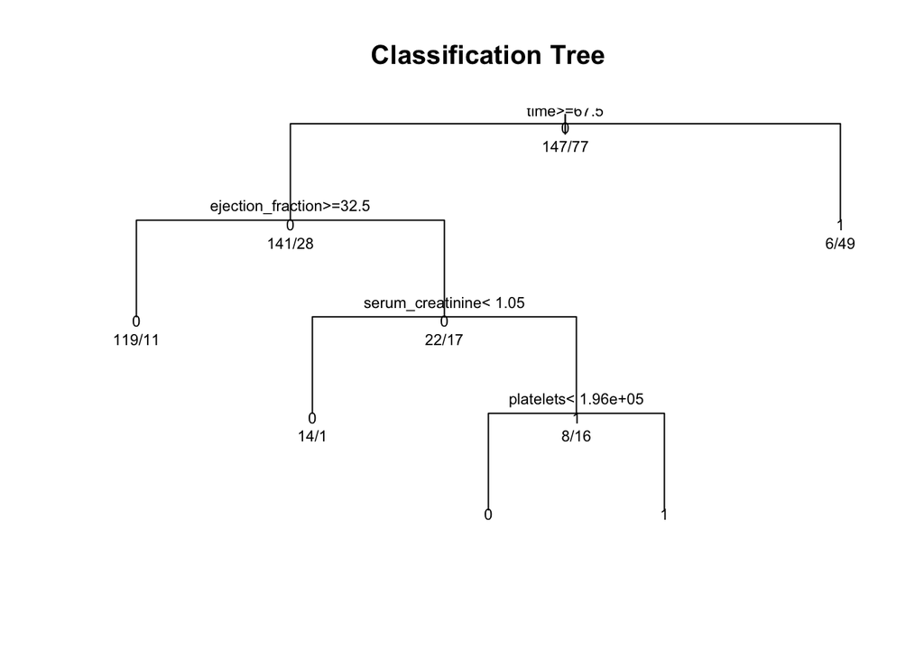

```r
plot(fit, uniform=TRUE, main="Classification Tree")
text(fit, use.n=TRUE, all=TRUE, cex= 0.7)
```

```r
# Accuracy Rate:
(conf.matrix = table(Actual = test$DEATH_EVENT, Predicted = predict(fit,test,type="class")))
```

```
##       Predicted
## Actual  0  1
##      0 44 12
##      1  4 15
```

```r
sum(diag(conf.matrix))/nrow(test) * 100
```

```
## [1] 78.66667
```

```r
confusionMatrix(conf.matrix)
```

```
## Confusion Matrix and Statistics
##
##       Predicted
## Actual  0  1
##      0 44 12
##      1  4 15
##
##                Accuracy : 0.7867
##                  95% CI : (0.6768, 0.8729)
##     No Information Rate : 0.64
##     P-Value [Acc > NIR] : 0.004518
##
##                   Kappa : 0.505
##
##  Mcnemar's Test P-Value : 0.080118
##
##             Sensitivity : 0.9167
##             Specificity : 0.5556
##          Pos Pred Value : 0.7857
##          Neg Pred Value : 0.7895
##              Prevalence : 0.6400
##          Detection Rate : 0.5867
##    Detection Prevalence : 0.7467
##       Balanced Accuracy : 0.7361
##
##        'Positive' Class : 0
##
```

### 6.4.1 Pruning:

```r
# Pruning
fitp = prune(fit, cp = 0.019608)
printcp(fitp)
```

```
##
## Classification tree:
## rpart(formula = DEATH_EVENT ~ ., data = training, method = "class")
##
## Variables actually used in tree construction:
## [1] ejection_fraction serum_creatinine  time
##
## Root node error: 77/224 = 0.34375
##
## n= 224
##
##         CP nsplit rel error  xerror     xstd
## 1 0.558442      0   1.00000 1.00000 0.092319
## 2 0.051948      1   0.44156 0.48052 0.072178
## 3 0.019608      3   0.33766 0.48052 0.072178
```

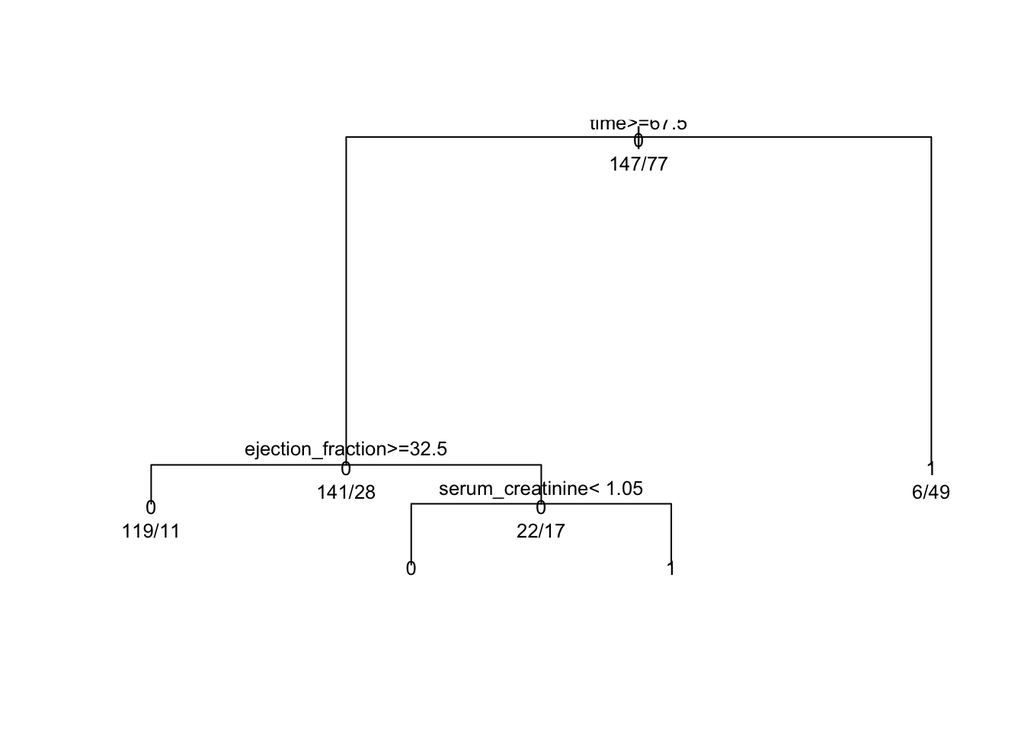

```r
plot(fitp) #plot smaller rpart object
text(fitp, use.n=TRUE, all=TRUE, cex=.8)
```

```r
(conf.matrix.prune = table(test$DEATH_EVENT, predict(fitp,test, type="class")))
```

```
##
##      0  1
##   0 42 14
##   1  4 15
```

```r
sum(diag(conf.matrix.prune))/nrow(test) * 100
```

```
## [1] 76
```

```r
confusionMatrix(conf.matrix.prune)
```

```
## Confusion Matrix and Statistics
##
##
##      0  1
##   0 42 14
##   1  4 15
##
##                Accuracy : 0.76
##                  95% CI : (0.6475, 0.8511)
##     No Information Rate : 0.6133
##     P-Value [Acc > NIR] : 0.005283
##
##                   Kappa : 0.4596
##
##  Mcnemar's Test P-Value : 0.033895
##
##             Sensitivity : 0.9130
##             Specificity : 0.5172
##          Pos Pred Value : 0.7500
##          Neg Pred Value : 0.7895
##              Prevalence : 0.6133
##          Detection Rate : 0.5600
##    Detection Prevalence : 0.7467
##       Balanced Accuracy : 0.7151
##
##        'Positive' Class : 0
##
```

## 6.5 Random Forest:

### 6.5.1 Using all variables:

#### 6.5.1.1 Hypertuning Parameter

```r
control <- trainControl(method="repeatedcv", number=10, repeats=3, search="random")
set.seed(4)
mtry <- sqrt(ncol(heartdata))
rf_random <- train(DEATH_EVENT~., data=heartdata, method="rf", metric='Accuracy', tuneLength=15, trControl=control)
print(rf_random)
```

```
## Random Forest
##
## 299 samples
##  12 predictor
##   2 classes: '0', '1'
##
## No pre-processing
## Resampling: Cross-Validated (10 fold, repeated 3 times)
## Summary of sample sizes: 269, 269, 269, 268, 269, 270, ...
## Resampling results across tuning parameters:
##
##   mtry  Accuracy   Kappa
##    1    0.7691954  0.3574794
##    2    0.8461884  0.6272339
##    3    0.8529675  0.6492393
##    4    0.8541169  0.6541063
##    5    0.8541144  0.6544194
##    6    0.8474478  0.6373658
##    7    0.8463367  0.6407240
##    8    0.8306612  0.6038030
##   10    0.8228068  0.5860266
##   12    0.8104672  0.5610446
##
## Accuracy was used to select the optimal model using the largest value.
## The final value used for the model was mtry = 4.
```

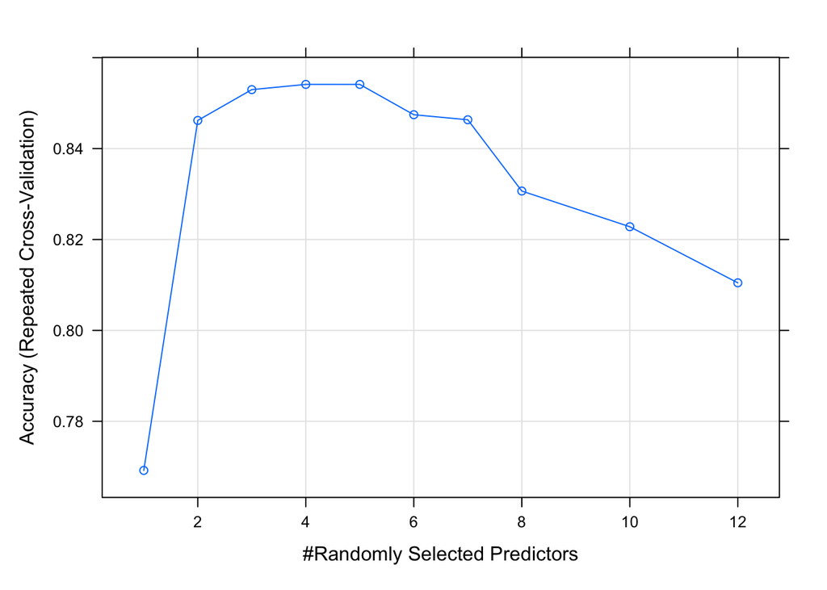

```r
plot(rf_random)
```

#### 6.5.1.2 Applying Model

```r
set.seed(4)
rf_model <- randomForest(x = training[,-13],
                         y = training$DEATH_EVENT,
                         ntree = 1000, mtry = 4)
y_pred = predict(rf_model, newdata = test[,-13])
table(y_pred,test$DEATH_EVENT)
```

```
##
## y_pred  0  1
##      0 48  4
##      1  8 15
```

```r
sum(diag(table(y_pred,test$DEATH_EVENT)))/nrow(test) * 100
```

```
## [1] 84
```

```r
confusionMatrix(table(y_pred,test$DEATH_EVENT))
```

```
## Confusion Matrix and Statistics
##
##
## y_pred  0  1
##      0 48  4
##      1  8 15
##
##                Accuracy : 0.84
##                  95% CI : (0.7372, 0.9145)
##     No Information Rate : 0.7467
##     P-Value [Acc > NIR] : 0.03754
##
##                   Kappa : 0.6046
##
##  Mcnemar's Test P-Value : 0.38648
##
##             Sensitivity : 0.8571
##             Specificity : 0.7895
##          Pos Pred Value : 0.9231
##          Neg Pred Value : 0.6522
##              Prevalence : 0.7467
##          Detection Rate : 0.6400
##    Detection Prevalence : 0.6933
##       Balanced Accuracy : 0.8233
##
##        'Positive' Class : 0
##
```

### 6.5.2 Using only model 2 variables:

```r
#Splitting into training and testing for Model 2:
set.seed(4)
heartdata2 <- heartdata[,c("age","ejection_fraction","serum_creatinine","serum_sodium","sex","time","DEATH_EVENT")]
n = nrow(heartdata)
split <- sample(1:n, 0.75*n, replace = FALSE)
training_model2 <- heartdata2[split,]
test_model2 <- heartdata2[-split,]
```

#### 6.5.2.1 Hypertuning Parameter

```r
control <- trainControl(method="repeatedcv", number=10, repeats=3, search="random")
set.seed(4)
mtry <- floor(sqrt(ncol(heartdata2)))
rf_random <- train(DEATH_EVENT~., data=heartdata2, method="rf", metric='Accuracy', tuneLength=15, trControl=control)
print(rf_random)
```

```
## Random Forest
##
## 299 samples
##   6 predictor
##   2 classes: '0', '1'
##
## No pre-processing
## Resampling: Cross-Validated (10 fold, repeated 3 times)
## Summary of sample sizes: 269, 269, 269, 268, 269, 270, ...
## Resampling results across tuning parameters:
##
##   mtry  Accuracy   Kappa
##   1     0.8540143  0.6458588
##   2     0.8450748  0.6386223
##   3     0.8394401  0.6255142
##   4     0.8406254  0.6299524
##   5     0.8284748  0.6003216
##   6     0.8285465  0.5998256
##
## Accuracy was used to select the optimal model using the largest value.
## The final value used for the model was mtry = 1.
```

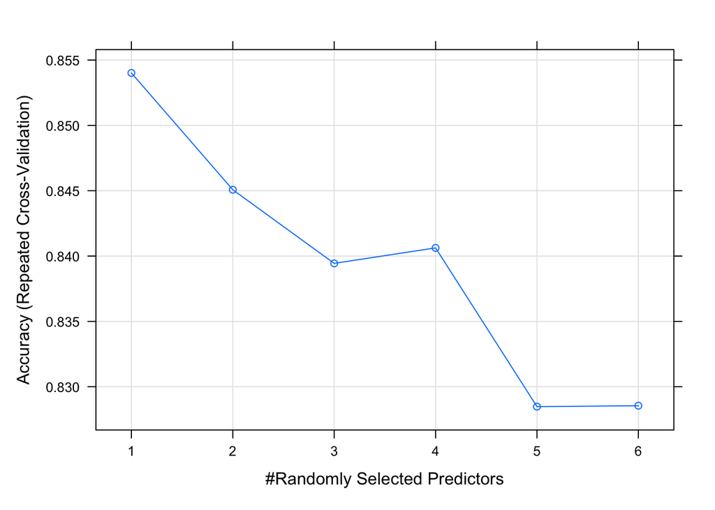

```r
plot(rf_random)
```

#### 6.5.2.2 Applying Model

```r
set.seed(4)
rf_model <- randomForest(x = training_model2[,-7],
                         y = training_model2$DEATH_EVENT,
                         ntree = 1000, mtry = 1)
y_pred = predict(rf_model, newdata = test_model2[,-7])
table(y_pred,test_model2$DEATH_EVENT)
```

```
##
## y_pred  0  1
##      0 52  5
##      1  4 14
```

```r
sum(diag(table(y_pred,test_model2$DEATH_EVENT)))/nrow(test_model2) * 100
```

```
## [1] 88
```

```r
confusionMatrix(table(y_pred,test_model2$DEATH_EVENT))
```

```
## Confusion Matrix and Statistics
##
##
## y_pred  0  1
##      0 52  5
##      1  4 14
##
##                Accuracy : 0.88
##                  95% CI : (0.7844, 0.9436)
##     No Information Rate : 0.7467
##     P-Value [Acc > NIR] : 0.003624
##
##                   Kappa : 0.6772
##
##  Mcnemar's Test P-Value : 1.000000
##
##             Sensitivity : 0.9286
##             Specificity : 0.7368
##          Pos Pred Value : 0.9123
##          Neg Pred Value : 0.7778
##              Prevalence : 0.7467
##          Detection Rate : 0.6933
##    Detection Prevalence : 0.7600
##       Balanced Accuracy : 0.8327
##
##        'Positive' Class : 0
##
```

## 6.6 KNN Algorithm

### 6.6.1 Using all variables:

```r
set.seed(4)
knn_mod <- knn(training,test,cl=training$DEATH_EVENT,k=6)
table(knn_mod,test$DEATH_EVENT)
```

```
##
## knn_mod  0  1
##       0 44 10
##       1 12  9
```

```r
sum(diag(table(knn_mod,test$DEATH_EVENT)))/nrow(test) * 100
```

```
## [1] 70.66667
```

```r
confusionMatrix(table(knn_mod,test$DEATH_EVENT))
```

```
## Confusion Matrix and Statistics
##
##
## knn_mod  0  1
##       0 44 10
##       1 12  9
##
##                Accuracy : 0.7067
##                  95% CI : (0.5902, 0.8062)
##     No Information Rate : 0.7467
##     P-Value [Acc > NIR] : 0.8245
##
##                   Kappa : 0.2507
##
##  Mcnemar's Test P-Value : 0.8312
##
##             Sensitivity : 0.7857
##             Specificity : 0.4737
##          Pos Pred Value : 0.8148
##          Neg Pred Value : 0.4286
##              Prevalence : 0.7467
##          Detection Rate : 0.5867
##    Detection Prevalence : 0.7200
##       Balanced Accuracy : 0.6297
##
##        'Positive' Class : 0
##
```

### 6.6.2 Using only variables from model 2:

```r
set.seed(9)
knn_mod <- knn(training_model2,test_model2,cl=training_model2$DEATH_EVENT,k=6)
table(knn_mod,test_model2$DEATH_EVENT)
```

```
##
## knn_mod  0  1
##       0 50  5
##       1  6 14
```

```r
sum(diag(table(knn_mod,test_model2$DEATH_EVENT)))/nrow(test_model2) * 100
```

```
## [1] 85.33333
```

```r
confusionMatrix(table(knn_mod,test$DEATH_EVENT))
```

```
## Confusion Matrix and Statistics
##
##
## knn_mod  0  1
##       0 50  5
##       1  6 14
##
##                Accuracy : 0.8533
##                  95% CI : (0.7527, 0.9244)
##     No Information Rate : 0.7467
##     P-Value [Acc > NIR] : 0.01899
##
##                   Kappa : 0.6189
##
##  Mcnemar's Test P-Value : 1.00000
##
##             Sensitivity : 0.8929
##             Specificity : 0.7368
##          Pos Pred Value : 0.9091
##          Neg Pred Value : 0.7000
##              Prevalence : 0.7467
##          Detection Rate : 0.6667
##    Detection Prevalence : 0.7333
##       Balanced Accuracy : 0.8148
##
##        'Positive' Class : 0
##
```

# 7 Conclusion

# 8 Reflection

1. Having more observations would have been better. It would have helped us in being more confident about the accuracy rates, and model selection.
2. Having longer followup period would have made data more reliable.

# 9 Citations

Davide Chicco, Giuseppe Jurman: “Machine learning can predict survival of patients with heart failure from serum creatinine and ejection fraction alone”. BMC Medical Informatics and Decision Making 20, 16 (2020). [Web Link](https://bmcmedinformdecismak.biomedcentral.com/articles/10.1186/s12911-020-1023-5)